# QTM 151 - Practice Quiz

**Submit as an HTML file** (see images below)

Step 1: Click the 3 dots in the toolbar for "More Actions"

[figure not shown]

Step 2: Choose "export"

[figure not shown]

Step 3: Select "HTML" from the dropdown window

[figure not shown]

Step 4: Select "Export" in the pop-up window.

[figure not shown]

Upload the .html file as your submission

Print your name below

```python
# Write your answer here

print('Soren Lee')
```

```
Soren Lee
```

This quiz is open book

- You can use the lecture notes
- You will get partial credit for attempting the questions
- To get full credit, the code should work as intended
- You should NOT communicate with other students

Print the following message:

"I will abide by Emory's code of conduct"

```python
# Write your answer here:
print("I will abide by Emory's code of conduct")
```

```
I will abide by Emory's code of conduct
```

(a) Checking If a Word is Part of a List

- Define a variable `topping1` with the value "mushrooms"
- Define a variable `topping2` with the value "pineapple"
- Define a list of pizza toppings with the values "cheese", "mushrooms", "pepperoni", and "onions"
- Write expressions to test whether `topping1` and `topping2` are contained in `pizza_toppings`  
  and print the outputs
- To get full points you must do all of the above tasks

Hint: Use the "in" command. The final output should be 2 True/False values.

```python
# Write your answer here:
topping1 = "mushrooms"
topping2 = "pineapple"
pizzatoppings = ["cheese", "mushrooms", "pepperoni", "onions"]
print(topping1 in pizzatoppings)
print(topping2 in pizzatoppings)
```

```
True
False
```

(b) Threshold testing a sum

- Create a numeric vector (**"vector" always means Numpy array**), $ c = \begin{bmatrix} 1 \\ 2 \\ 3 \end{bmatrix} $
- Use the "numpy.sum()"' function to add up the individual elements.
- If the sum of numbers is higher than $5$, write a message saying  
  " The sum is greater than or equal to 5"
- Otherwise show a message "It is strictly less than 5"

```python
# Write your answer here:
import numpy as np
import pandas as pd
c = [1,2,3]
if np.sum(c) >= 5:
    print("The sum is greater than or equal to 5")
else:
    print('it is strictly less than 5')
```

```
The sum is greater than or equal to 5
```

### c) For-loops + Plotting

- Create an array of x-values with 100 evenly spaced points between $0$ and $2\pi$  
  using `np.linspace()`. **Hint**: type `help(np.linspace)` in a separate cell to see how it is used
- Create a vector named `vec_y1` where each element is computed from the formula  
  $ y_k = \sin(x_k)$. (Here $x_k$ is the $k$-th element of the array you created above, and $y_k$ is the $k$-th element of vec_y1)
- Create a vector `vec_y2` where each element is computed from the formula  
  $ y_k = \cos(x_k)$.
- Create a list `list_vectors` with elements `vec_y1` and `vec_y2`. (So a list with two components, both being numpy arrays)
- Create a for-loop that goes through each element of `list_vectors` and plots each  
  list of $y$ values on the vertical axis against $x$ on the horizontal axis.

Note: The final output should be a 2-dimensional plot with the values from vec_y1 and vec_y2 on the vertical axis, and the $x$ values on the horizontal axis. **Remember to label the axes and add a title to the plot**.

[output not shown]

[output cut: 53 more lines]

[output not shown]

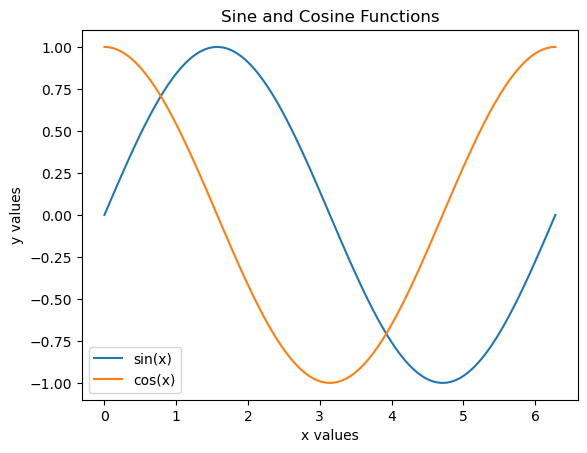

```python
# Write your answer here:
import matplotlib.pyplot as plt
help(np.linspace)
x_vals = np.linspace(0, 2 * np.pi, 100)

vec_y1 = np.sin(x_vals)

vec_y2 = np.cos(x_vals)

list_vectors = [vec_y1, vec_y2]

for y_vals in list_vectors:
    plt.plot(x_vals, y_vals)

plt.xlabel('x values')
plt.ylabel('y values')
plt.title('Sine and Cosine Functions')
plt.legend(['sin(x)', 'cos(x)'])
plt.show()
```

(d) Creating a scatter plot

Using NumPy arrays, create a scatter plot of the function

$q(x) = \sin(\pi x) + 1$

at a set of points in the interval $0 \leq x \leq 2$

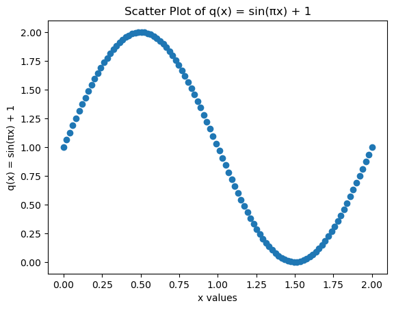

```python
# Write your answer here:

x_vals = np.linspace(0, 2, 100)

q_vals = np.sin(np.pi * x_vals) + 1

plt.scatter(x_vals, q_vals)

plt.xlabel('x values')
plt.ylabel('q(x) = sin(πx) + 1')
plt.title('Scatter Plot of q(x) = sin(πx) + 1')

plt.show()
```

(e) Open the dataset "united_states_co2_emissions.csv" in the "practice_quiz_data" folder using pandas

- Assign it to a variable named "us_emissions"
- Note: This contains CO2 emissions (in kilotons) by the United States from 1960-2019.  
  It is compiled from various sources, including the United Nations Framework Convention  
  on Climate Change (UNFCCC) and the International Energy Agency (IEA).

```python
# Write your answer here:
us_emissions = pd.read_csv("practice_quiz_data/united_states_co2_emissions.csv")
print (us_emissions)
```

```
    year  total_emissions
0   1960     2.890696e+06
1   1961     2.880506e+06
2   1962     2.987208e+06
3   1963     3.119231e+06
4   1964     3.255995e+06
5   1965     3.390923e+06
6   1966     3.561878e+06
7   1967     3.695709e+06
8   1968     3.831355e+06
9   1969     4.024749e+06
10  1970     4.328905e+06
11  1971     4.356770e+06
12  1972     4.564953e+06
13  1973     4.770195e+06
```

[output cut: 46 more lines]

(f) View the dataset and create a list of variable names

- The us_emissions dataset has two named column headings.
- Create a list containing two strings, one for each of the column headings.
- The strings must match the headings **exactly** (the "#" symbols shown in DataWrangler are not part of the name). Otherwise you will run into a problem in part d)
- Assign this list to a variable called "columns"
- You do not have to "extract" the names from the dataset through a Python command. You can simply type them manually.

```python
# Write your answer here:
columns = ["year", "total_emissions"]
us_emissions[columns[1]].describe()
```

```
count    6.000000e+01
mean     4.733944e+06
std      7.568200e+05
min      2.880506e+06
25%      4.457976e+06
50%      4.862075e+06
75%      5.160723e+06
max      5.775810e+06
Name: total_emissions, dtype: float64
```